# Zack Loken Lab Exercise 2 - Data Analysis in R

### 1. What is the second argument in the lm() function?

##### The second argument in the lm() function is data - which allows you to manually enter values for the model variables. This was found by running the command ?lm() and then reviewing the arguments listed in the R documentation for Fitting Linear Models.

```r
?lm()
```

### 2. What is the second argument in the plot.gam() function found in the mgcv library?

##### The second argument in the plot.gam() function is residuals; if true then partial residuals are added to plots. This was found by installing the mgcv package and then typing ?plot.gam(). We can then review arguments listed in the R documentation for Default GAM plotting.

```r
install.packages("mgcv")
library(mgcv)
?plot.gam()
```

### 3. What is the length of the vector created from a sequence of 3 to 27 by intervals of 0.13?

##### The vector length of this output is 185.

```r
v <- seq(3, 27, by=0.13)
length(v)
```

```
## [1] 185
```

### 4. What code subsets the first row and third column of the second matrix for the array ‘array(seq(1:20)), dim=c(2,5,2))’ and what number occupies this position?

##### The code that subsets the first row and third column of the second matrix for this array is ‘a[1, 3, 2]’ and the number that occupies this position is 15.

```r
a <- array(seq(1:20), dim=c(2,5,2))
a[1, 3, 2]
```

```
## [1] 15
```

### 5. Create a list object from 3 or more built in datasets.

```r
data(package = .packages(all.available = TRUE))
data("rivers")
data("USArrests")
data("precip")
data("rock")
ListObject <- list(rivers, USArrests, precip, rock)
str(ListObject)
```

```
## List of 4
##  $ : num [1:141] 735 320 325 392 524 ...
##  $ :'data.frame':    50 obs. of  4 variables:
##   ..$ Murder  : num [1:50] 13.2 10 8.1 8.8 9 7.9 3.3 5.9 15.4 17.4 ...
##   ..$ Assault : int [1:50] 236 263 294 190 276 204 110 238 335 211 ...
##   ..$ UrbanPop: int [1:50] 58 48 80 50 91 78 77 72 80 60 ...
##   ..$ Rape    : num [1:50] 21.2 44.5 31 19.5 40.6 38.7 11.1 15.8 31.9 25.8 ...
##  $ : Named num [1:70] 67 54.7 7 48.5 14 17.2 20.7 13 43.4 40.2 ...
##   ..- attr(*, "names")= chr [1:70] "Mobile" "Juneau" "Phoenix" "Little Rock" ...
##  $ :'data.frame':    48 obs. of  4 variables:
##   ..$ area : int [1:48] 4990 7002 7558 7352 7943 7979 9333 8209 8393 6425 ...
##   ..$ peri : num [1:48] 2792 3893 3931 3869 3949 ...
##   ..$ shape: num [1:48] 0.0903 0.1486 0.1833 0.1171 0.1224 ...
##   ..$ perm : num [1:48] 6.3 6.3 6.3 6.3 17.1 17.1 17.1 17.1 119 119 ...
```

### 6. What is the mean length of major North American Rivers (‘rivers’ built-in dataset)

##### The mean length of major North American Rivers is 591.2 units

```r
data("rivers")
summary(rivers)
```

```
##    Min. 1st Qu.  Median    Mean 3rd Qu.    Max.
##   135.0   310.0   425.0   591.2   680.0  3710.0
```

### 7. Write a built-in dataset to a CSV file (show code) and open it in Excel.

```r
data("PlantGrowth")
write.csv(PlantGrowth,
          "D:/Zack/School/Classes/Spring 22/OCS 7131 - Data Analysis in R/Lab/Lab 1/PlantGrowth.csv",
          row.names=TRUE)
```

### 8. Tabulate the type and concentration factors in the CO2 dataset in one table. Is this experiment balanced?

##### See code below. This experiment is balanced because there are an equal number of observations at each concentration level for Quebec and Mississippi (values in the ‘Type’ column).

```r
data("CO2")
table(CO2$Type, CO2$conc)
```

```
##
##               95 175 250 350 500 675 1000
##   Quebec       6   6   6   6   6   6    6
##   Mississippi  6   6   6   6   6   6    6
```

### 9. Write a single function to subset both spray A and records of counts > 17 from ‘InsectSprays’. How many records are there?

##### There are 3 records with spray type A and count greater than 17.

```r
data("InsectSprays")
subset(InsectSprays, spray=='A' & count > 17, select = c(spray, count))
```

```
##    spray count
## 3      A    20
## 8      A    23
## 10     A    20
```

### 10. Create a box plot of the spray counts in ‘InsectSprays’.

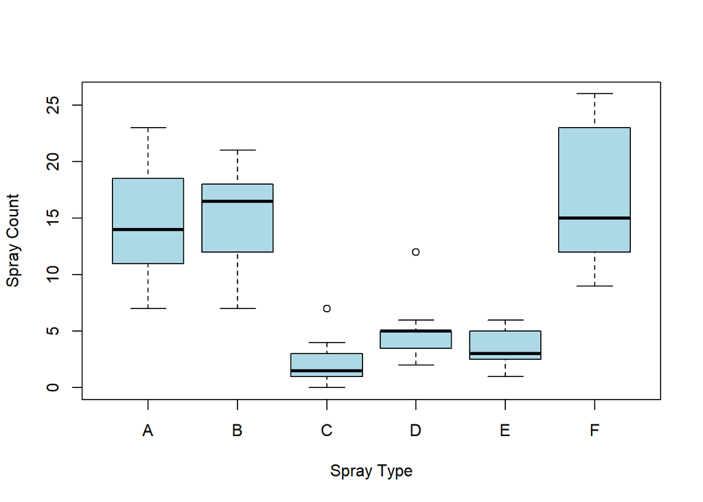

```r
data("InsectSprays")
boxplot(count ~ spray, data = InsectSprays,
        xlab = "Spray Type",
        ylab = "Spray Count",
        col = "lightblue")
```